# Example BBS trends analysis

83 species from 1992 - 2021

Nicholas Clark, School of Veterinary Science, University of Queensland[^1]

## Source libraries

```r
library(mgcv)
library(dplyr)
library(ggplot2)
library(marginaleffects)
source('Functions/utilities.R')
```

## Model summary and AIC calculation

```r
load("./data/model_objects.rda")
mod <- readRDS("./models/mod.rds")
```

Don’t run full `mgcv` summaries; they are extremely computationally expensive for these models

```r
summary(mod, re.test = FALSE)
```

```
##
## Family: poisson
## Link function: log
##
## Formula:
## count ~ offset(offset) + s(year, bs = "cr", k = 10) + s(sp_latin_phy,
##     bs = "mrf", xt = list(penalty = phylo_penalty), k = 20) +
##     s(ST_12, bs = "mrf", xt = list(nb = strat_penalty), k = 20) +
##     ti(year, ST_12, bs = c("cr", "mrf"), xt = list(list(penalty = NULL),
##         list(nb = strat_penalty)), k = c(10, 20)) + ti(ST_12,
##     sp_latin_phy, bs = c("mrf", "mrf"), xt = list(list(nb = strat_penalty),
##         list(penalty = phylo_penalty)), k = c(20, 20)) + ti(year,
##     sp_latin_phy, bs = c("cr", "mrf"), xt = list(list(penalty = NULL),
##         list(penalty = phylo_penalty)), k = c(10, 20)) + ti(year,
##     ST_12, sp_latin_phy, bs = c("cr", "mrf", "mrf"), xt = list(list(penalty = NULL),
##         list(nb = strat_penalty), list(penalty = phylo_penalty)),
##     k = c(10, 20, 20)) + ti(year, ST_12, sp_latin, bs = c("cr",
##     "mrf", "mrf"), xt = list(list(penalty = NULL), list(nb = strat_penalty),
##     list(penalty = sp_penalty)), k = c(10, 20, 20))
##
## Parametric coefficients:
##              Estimate Std. Error z value Pr(>|z|)
## (Intercept) -1.097124   0.007141  -153.6   <2e-16 ***
## ---
## Signif. codes:  0 '***' 0.001 '**' 0.01 '*' 0.05 '.' 0.1 ' ' 1
##
## Approximate significance of smooth terms:
##           edf Ref.df Chi.sq p-value
## s(year) 8.893  8.916  534.2  <2e-16 ***
## ---
## Signif. codes:  0 '***' 0.001 '**' 0.01 '*' 0.05 '.' 0.1 ' ' 1
##
## R-sq.(adj) =  0.991   Deviance explained = 99.2%
## fREML = 3.0144e+05  Scale est. = 1         n = 86652
```

AIC is available, if we choose to use it

```r
AIC(mod)
```

```
## [1] 796685.8
```

## Contributions to ‘wiggliness’

Calculate phylogenetic contributions to species’ nonlinear trend estimates. This works by taking advantage of the `predict.gam(type = 'terms', ...)` functionality in `mgcv`. Essentially we compute the partial contribution of *each* term in the fitted model to the nonlinear trend estimate for each species x region combination. Summing these contributions gives the trend estimate for each row in `newdata`, while taking the squared second derivative of this sum gives the *slope of the slope* for each row. If we sum these squared second derivatives we arrive at a useful definition of “wiggliness”. The idea of the `compute_derivs()` function is to do this while either excluding phylogenetic terms or excluding all terms apart from the phylogenetic terms. This allows us to isolate the partial contribution of phylogeny to the overall wigliness (i.e. nonlinearity) of a species’ trend estimate. It is computationally expensive so I operate over 8 cores here

```r
phylo_derivs <- compute_derivs(mod_data,
                               model = mod,
                               type = 'phylogenetic',
                               n_cores = 8)
```

There is also a work-in-progress plotting routine for the returned object. In this plot, bluer shades show higher contributions of phylogeny, while redder shades show smaller contributions of phylogeny. They are plotted on the log scale, so a value of `0` means phylogeny contributes equally compared to all other non-phylogenetic components (space and non-phylogenetic relationships)

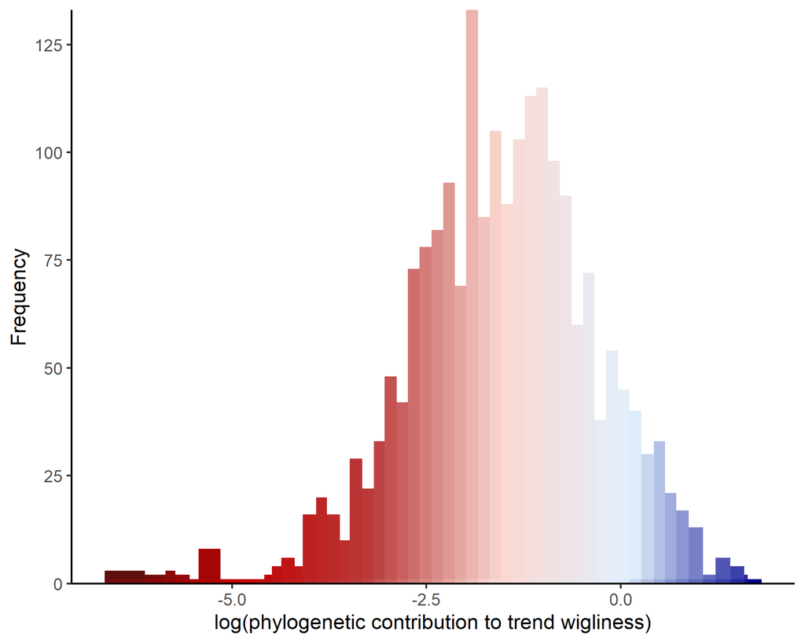

```r
plot_trait_conts(trait_derivs = phylo_derivs,
                 type = 'phylogenetic')
```

We can see that, indeed for some species phylogeny plays a sizeable role. Here I compute the proportion of trends in which phylogenetic information contributes at least 50% to the estimated wiggliness of the function compared to other information (i.e. spatial and non-phylogenetic variation). This is an arbitrary threshold of course

```r
phylo_derivs %>%
  # Filter out those with very small wiggliness estimates, as
  # the contributions don't add any meaningful information here
  # because the estimated trend is flat
  dplyr::filter(wiggliness >= quantile(wiggliness, probs = 0.15)) %>%
  dplyr::summarise(prop = 100 * length(which(trait_conts >= 0.5)) /
                     dplyr::n())
```

```
##       prop
## 1 23.33659
```

## Plotting trends

Plot some predictions against truth (note, these predictions will not include contributions from the residual AR process). The `plot_sp_trends()` function will take the supplied data and compute predictions that include the offset terms, so what we are seeing is a combination of the estimated trend and the supplied offset. We can supply specific regions we’d want, but I’m just using the default here. These give us a sense of whether the model has done a reasonable job of capturing the complexity of the observations. For some species it is clear that we’d need more complexity (i.e. higher `k` values for some of the smooth terms)

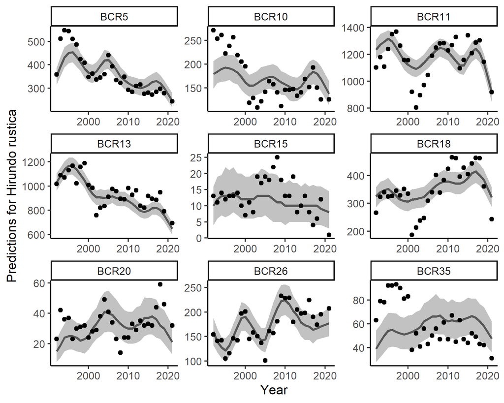

```r
plot_sp_trends(model = mod,
               data = mod_data,
               species = 'Hirundo_rustica',
               type = 'response',
               median_records = FALSE)
```

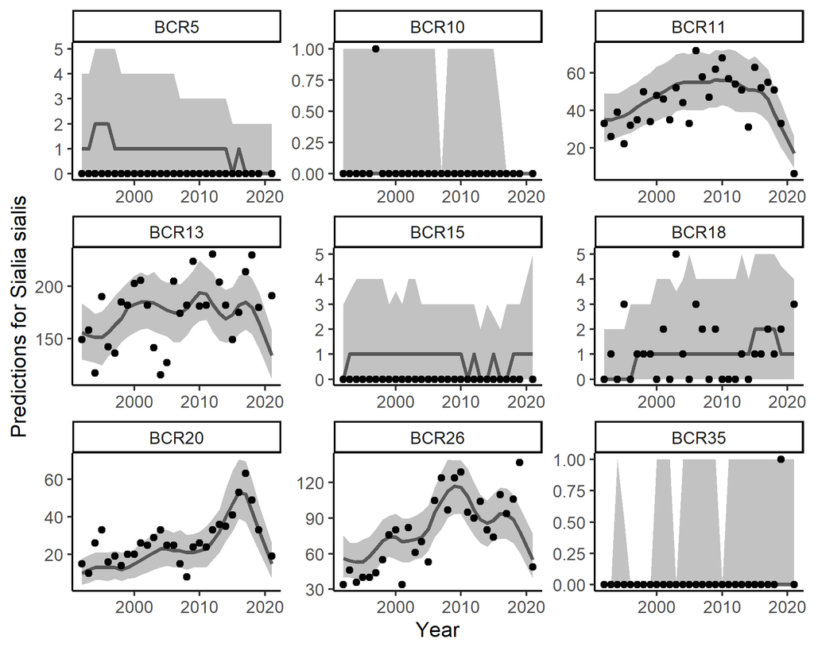

```r
plot_sp_trends(model = mod,
               data = mod_data,
               species = levels(mod_data$sp_latin)[8],
               type = 'response',
               median_records = FALSE)
```

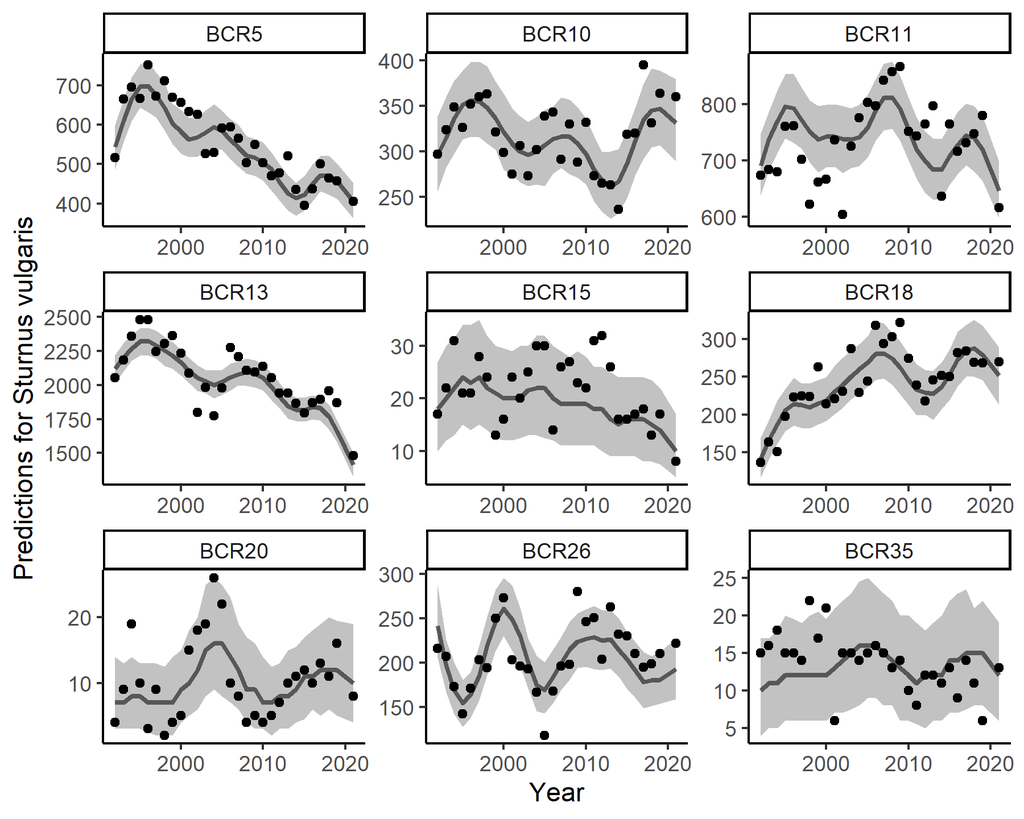

```r
plot_sp_trends(model = mod,
               data = mod_data,
               species = levels(mod_data$sp_latin)[9],
               type = 'response',
               median_records = FALSE)
```

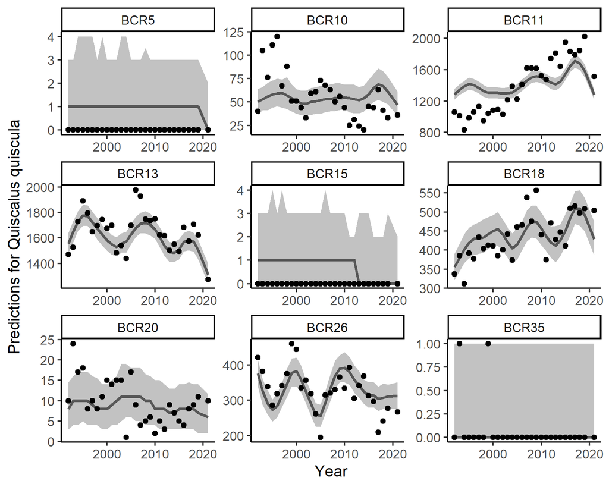

```r
plot_sp_trends(model = mod,
               data = mod_data,
               species = levels(mod_data$sp_latin)[30],
               type = 'response',
               median_records = FALSE)
```

We can also plot some expected trends by fixing the offsets and asking how the model would expect species’ abundances to change over time. This is a more useful way of asking what the estimated trend is for each species x region combination, because it gives what the model would expect to see if we had a standardized sampling effort per year

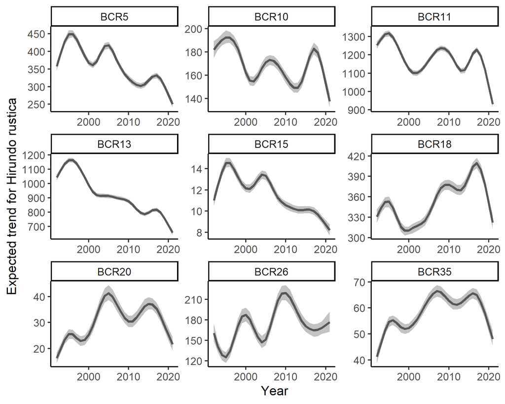

```r
plot_sp_trends(model = mod,
               data = mod_data,
               species = 'Hirundo_rustica',
               type = 'expected',
               median_records = TRUE)
```

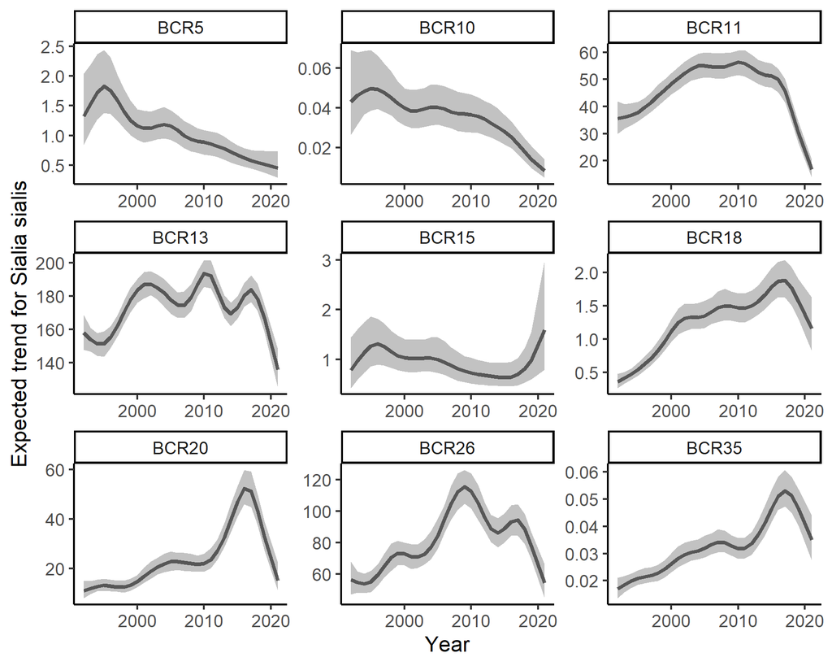

```r
plot_sp_trends(model = mod,
               data = mod_data,
               species = levels(mod_data$sp_latin)[8],
               type = 'expected',
               median_records = TRUE)
```

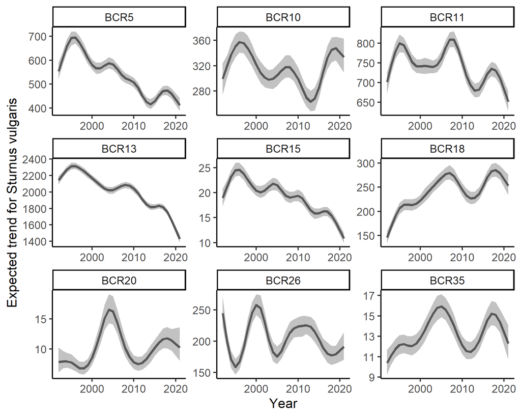

```r
plot_sp_trends(model = mod,
               data = mod_data,
               species = levels(mod_data$sp_latin)[9],
               type = 'expected',
               median_records = TRUE)
```

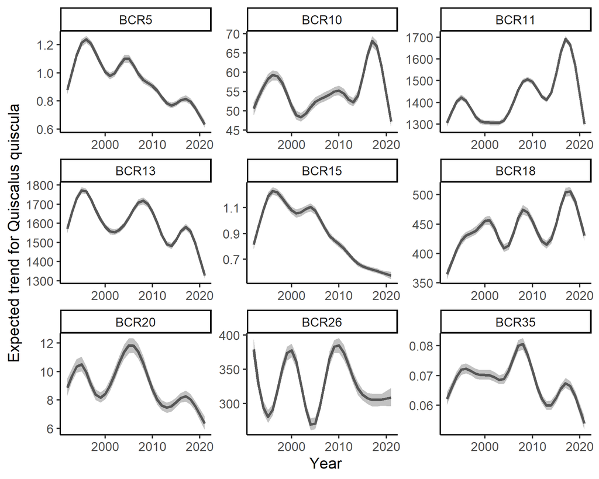

```r
plot_sp_trends(model = mod,
               data = mod_data,
               species = levels(mod_data$sp_latin)[30],
               type = 'expected',
               median_records = TRUE)
```

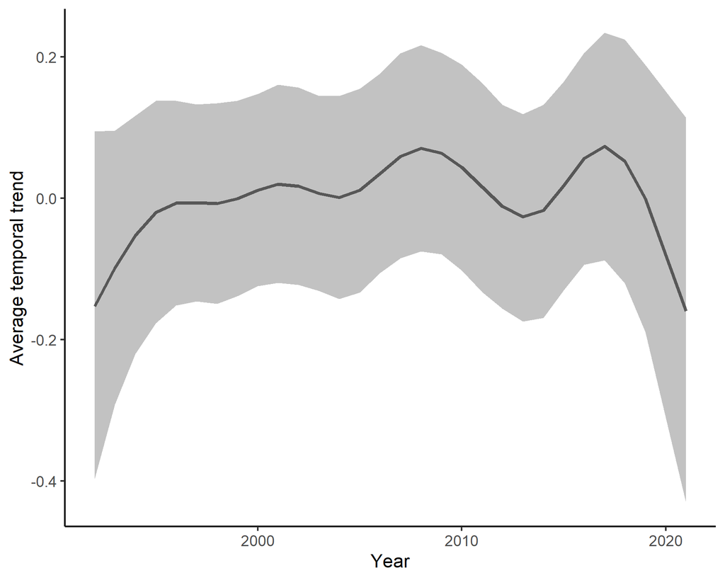

```r
plot_av_trend(model = mod, mod_data = mod_data,
              prop_species = 0.65)
```